# Projet : Super Market Sales Visualizations

Tek-Up School

2023-2024

## Présenté par :

- Nour Baklouti
- Rania Dridi

## Encadré par :

- Dr. Nadjib Mohamed Mehdi BENDAOUD

## Supermarket Data Visualization

Ce rapport vise à visualiser et à analyser :

1.La relation des clients avec le supermarché.

2.Les méthodes de paiement utilisées dans le supermarché.

3.La relation entre les produits et les quantités.

4.Les produits et leurs évaluations.

5.Les types de produits et leurs ventes.

=> Pour plus d’informations, vous trouverez ci-joint le lien vers notre notebook Kaggle.

https://www.kaggle.com/code/nourbaklouti/bi-supermarket.

## Résumé du DataFrame

```r
library(ggplot2)
library(tidyverse)
basesm<-read.csv("C:/Users/nourb/Desktop/SupermarketSales/bdsupermarket_sales.csv")



summary(basesm)
```

```
##   Invoice.ID           Branch              City           Customer.type
##  Length:1000        Length:1000        Length:1000        Length:1000
##  Class :character   Class :character   Class :character   Class :character
##  Mode  :character   Mode  :character   Mode  :character   Mode  :character
##
##
##
##     Gender          Product.line         Unit.price       Quantity
##  Length:1000        Length:1000        Min.   :10.08   Min.   : 1.00
##  Class :character   Class :character   1st Qu.:32.88   1st Qu.: 3.00
##  Mode  :character   Mode  :character   Median :55.23   Median : 5.00
##                                        Mean   :55.67   Mean   : 5.51
##                                        3rd Qu.:77.94   3rd Qu.: 8.00
##                                        Max.   :99.96   Max.   :10.00
##      Tax.5.            Total             Date               Time
##  Min.   : 0.5085   Min.   :  10.68   Length:1000        Length:1000
##  1st Qu.: 5.9249   1st Qu.: 124.42   Class :character   Class :character
##  Median :12.0880   Median : 253.85   Mode  :character   Mode  :character
##  Mean   :15.3794   Mean   : 322.97
##  3rd Qu.:22.4453   3rd Qu.: 471.35
##  Max.   :49.6500   Max.   :1042.65
##    Payment               cogs        gross.margin.percentage  gross.income
##  Length:1000        Min.   : 10.17   Min.   :4.762           Min.   : 0.5085
##  Class :character   1st Qu.:118.50   1st Qu.:4.762           1st Qu.: 5.9249
##  Mode  :character   Median :241.76   Median :4.762           Median :12.0880
##                     Mean   :307.59   Mean   :4.762           Mean   :15.3794
##                     3rd Qu.:448.90   3rd Qu.:4.762           3rd Qu.:22.4453
##                     Max.   :993.00   Max.   :4.762           Max.   :49.6500
##      Rating
##  Min.   : 4.000
##  1st Qu.: 5.500
##  Median : 7.000
##  Mean   : 6.973
##  3rd Qu.: 8.500
##  Max.   :10.000
```

# Description des variables

Les variables présentes dans le jeu de données sont les suivantes :

- Invoice ID : Identifiant unique de la facture.
- Branch : Succursale du supermarché (A, B, C).
- City :Ville où se trouve le supermarché.
- Customer type :Type de client (Member pour membre, Normal pour non-membre).
- Gender : Genre du client (Male pour homme, Female pour femme).
- Product line :Catégorie du produit.
- Unit price : Prix unitaire du produit.
- Quantity :Quantité d’articles achetés.
- Tax 5% : Montant de la taxe (5%) sur l’achat.
- Total :Montant total de l’achat (y compris la taxe).
- Date : Date de l’achat .
- Time : Heure de l’achat .
- Payment : Mode de paiement (Ewallet, Cash, Credit card).
- cogs (Cost of Goods Sold) :Coût des biens vendus.
- gross margin percentage :Pourcentage de  
  marge brute.
- gross income : Revenu brut
- Rating : Évaluation du client pour l’expérience d’achat

# Visualization des données

## La relation des clients avec le supermarché:

# la distribution par genre

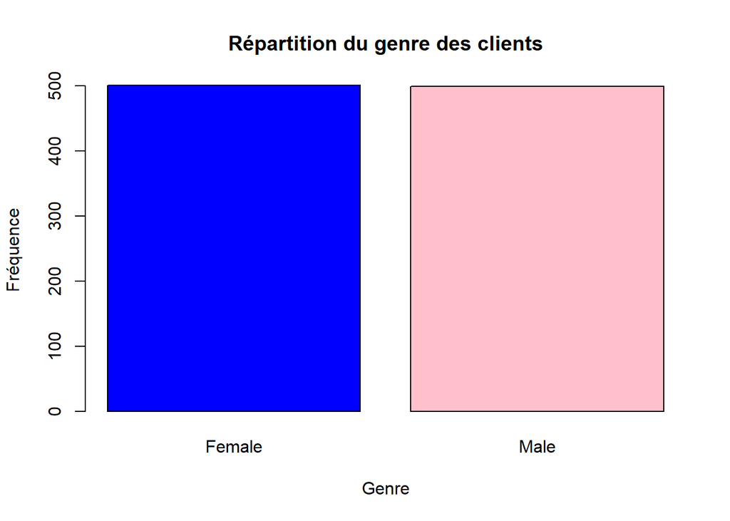

```r
barplot(table(basesm$Gender), col = c("blue", "pink"),
        main = "Répartition du genre des clients",
        xlab = "Genre", ylab = "Fréquence")
```

# La distribution du type de client

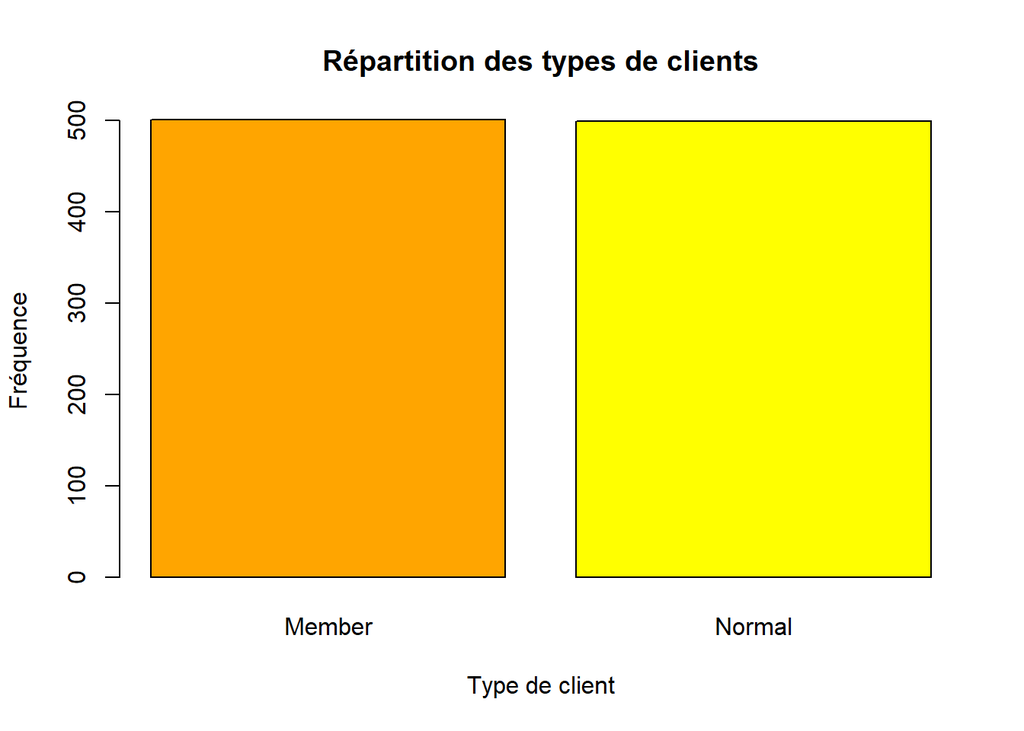

```r
barplot(table(basesm$Customer.type), col = c("orange", "yellow", "green"),
        main = "Répartition des types de clients",
        xlab = "Type de client", ylab = "Fréquence")
```

=> Ce graphique illustre la répartition des types de clients dans le supermarché, distinguant entre les membres (Member) et les clients non-membres (Normal). On conclut qu’il ya autant des membres que des clients normaux.